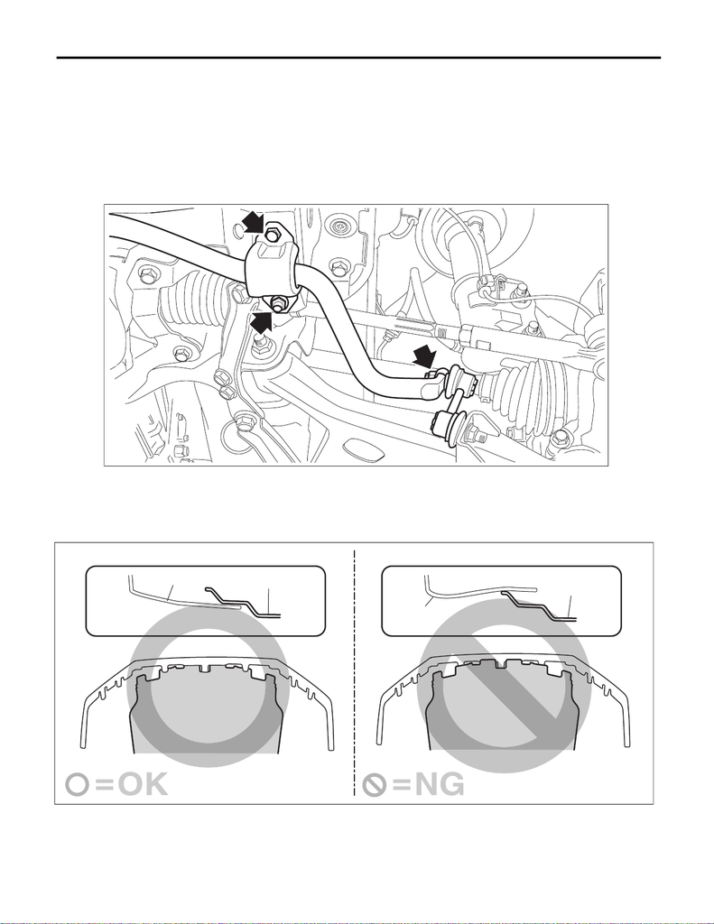

FS-31

Front Stabilizer

FRONT SUSPENSION

5. Front Stabilizer

A: REMOVAL

1) Lift up the vehicle, and then remove the left and right front wheels.

2) Remove the under cover - front. <Ref. to EI-21, REMOVAL, Front Under Cover.>

3) Remove the front crossmember support. <Ref. to FS-29, REMOVAL, Front Crossmember Support Plate.>

4) Remove the front stabilizer.

(1) Remove the left and right stabilizer links.

(2) Remove the clamp - stabilizer bushing on the left and right sides.

B: INSTALLATION

CAUTION:

FS-00504

EI-04291

(b)

(a)

(b)

(a)

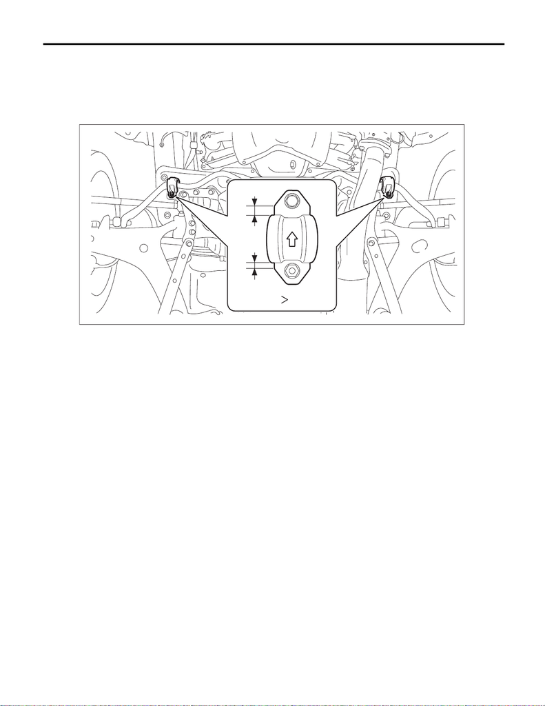

FS-32

Front Stabilizer

FRONT SUSPENSION

1) Before installation, inspect the following items and replace any faulty part with a new one.

• Check the bushing - stabilizer for abnormal cracks, fatigue or damage.

• Check the stabilizer link assembly for damage.

2) Install the front stabilizer.

CAUTION:

Install the clamp - stabilizer bushing with the arrow mark facing the front of the vehicle.

Tightening torque:

Stabilizer link assembly: 60 N·m (6.1 kgf-m, 44.3 ft-lb)

Clamp - stabilizer: 25 N·m (2.5 kgf-m, 18.4 ft-lb)

3) Install the front crossmember support.

Tightening torque:

4) Install the under cover - front. <Ref. to EI-22, INSTALLATION, Front Under Cover.>

5) Lower the vehicle, and install the front wheels.

Tightening torque:

120 N·m (12.2 kgf-m, 88.5 ft-lb)

FS-00656

A

B

AB